# A Study of Water Potability

An attempt on understanding what makes water potable based on 10 different numerical features. The water_potability.csv file contains water quality metrics for 3276 different water bodies and It's source can be found here: https://www.kaggle.com/datasets/adityakadiwal/water-potability?datasetId=1292407&sortBy=voteCount

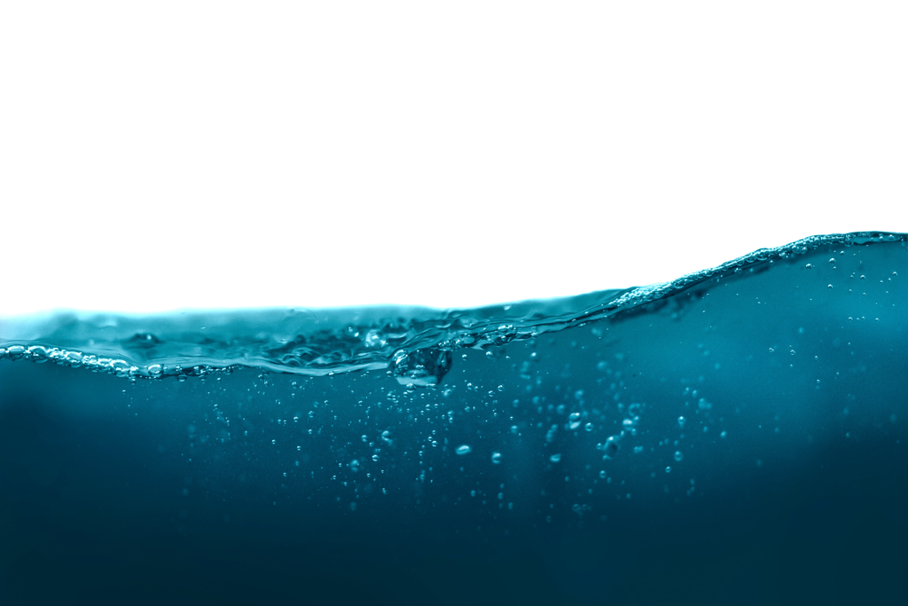

Foto de Daniel Sinoca en Unsplash.

## Feature Definitions:

**1. pH value:** PH is an important parameter in evaluating the acid–base balance of water. It is also the indicator of acidic or alkaline condition of water status. WHO has recommended maximum permissible limit of pH from 6.5 to 8.5. The current investigation ranges were 6.52–6.83 which are in the range of WHO standards.

**2. Hardness:** Hardness is mainly caused by calcium and magnesium salts. These salts are dissolved from geologic deposits through which water travels. The length of time water is in contact with hardness producing material helps determine how much hardness there is in raw water. Hardness was originally defined as the capacity of water to precipitate soap caused by Calcium and Magnesium.

**3. Solids (Total dissolved solids - TDS):** Water has the ability to dissolve a wide range of inorganic and some organic minerals or salts such as potassium, calcium, sodium, bicarbonates, chlorides, magnesium, sulfates etc. These minerals produced un-wanted taste and diluted color in appearance of water. This is the important parameter for the use of water. The water with high TDS value indicates that water is highly mineralized. Desirable limit for TDS is 500 mg/l and maximum limit is 1000 mg/l which prescribed for drinking purpose.

**4. Chloramines:** Chlorine and chloramine are the major disinfectants used in public water systems. Chloramines are most commonly formed when ammonia is added to chlorine to treat drinking water. Chlorine levels up to 4 milligrams per liter (mg/L or 4 parts per million (ppm)) are considered safe in drinking water.

**5. Sulfate:** Sulfates are naturally occurring substances that are found in minerals, soil, and rocks. They are present in ambient air, groundwater, plants, and food. The principal commercial use of sulfate is in the chemical industry. Sulfate concentration in seawater is about 2,700 milligrams per liter (mg/L). It ranges from 3 to 30 mg/L in most freshwater supplies, although much higher concentrations (1000 mg/L) are found in some geographic locations.

**6. Conductivity:** Pure water is not a good conductor of electric current rather’s a good insulator. Increase in ions concentration enhances the electrical conductivity of water. Generally, the amount of dissolved solids in water determines the electrical conductivity. Electrical conductivity (EC) actually measures the ionic process of a solution that enables it to transmit current. According to WHO standards, EC value should not exceeded 400 μS/cm.

**7. Organic_carbon:** Total Organic Carbon (TOC) in source waters comes from decaying natural organic matter (NOM) as well as synthetic sources. TOC is a measure of the total amount of carbon in organic compounds in pure water. According to US EPA < 2 mg/L as TOC in treated / drinking water, and < 4 mg/Lit in source water which is use for treatment.

**8. Trihalomethanes:** THMs are chemicals which may be found in water treated with chlorine. The concentration of THMs in drinking water varies according to the level of organic material in the water, the amount of chlorine required to treat the water, and the temperature of the water that is being treated. THM levels up to 80 ppm is considered safe in drinking water.

**9. Turbidity:** The turbidity of water depends on the quantity of solid matter present in the suspended state. It is a measure of light emitting properties of water and the test is used to indicate the quality of waste discharge with respect to colloidal matter. The mean turbidity value obtained for Wondo Genet Campus (0.98 NTU) is lower than the WHO recommended value of 5.00 NTU.

**10. Potability:** Indicates if water is safe for human consumption where 1 means Potable and 0 means Not potable.

## Import packages --------------------------------------------------------------------------------------

```python
import numpy as np
import pandas as pd
import matplotlib.pyplot as plt
%matplotlib inline
plt.rcParams["figure.figsize"] = (20,10)
import seaborn as sns

from sklearn.preprocessing import StandardScaler
from sklearn.model_selection import train_test_split, GridSearchCV
from sklearn.pipeline import Pipeline
```

## Data import & Exploration -------------------------------------------------------------------------

```python
# set seed
seed = 42
np.random.seed(seed)

# Import and show data.
file = 'data/water_potability.csv'
data = pd.read_csv(file)
data.head()
```

|  | ph | Hardness | Solids | Chloramines | Sulfate | Conductivity | Organic_carbon | Trihalomethanes | Turbidity | Potability |
| --- | --- | --- | --- | --- | --- | --- | --- | --- | --- | --- |
| 0 | NaN | 204.890455 | 20791.318981 | 7.300212 | 368.516441 | 564.308654 | 10.379783 | 86.990970 | 2.963135 | 0 |
| 1 | 3.716080 | 129.422921 | 18630.057858 | 6.635246 | NaN | 592.885359 | 15.180013 | 56.329076 | 4.500656 | 0 |
| 2 | 8.099124 | 224.236259 | 19909.541732 | 9.275884 | NaN | 418.606213 | 16.868637 | 66.420093 | 3.055934 | 0 |
| 3 | 8.316766 | 214.373394 | 22018.417441 | 8.059332 | 356.886136 | 363.266516 | 18.436524 | 100.341674 | 4.628771 | 0 |
| 4 | 9.092223 | 181.101509 | 17978.986339 | 6.546600 | 310.135738 | 398.410813 | 11.558279 | 31.997993 | 4.075075 | 0 |

```python
# Show data types, nulls, features, and dimensions.
data.info()
```

```
<class 'pandas.core.frame.DataFrame'>
RangeIndex: 3276 entries, 0 to 3275
Data columns (total 10 columns):
 #   Column           Non-Null Count  Dtype
---  ------           --------------  -----
 0   ph               2785 non-null   float64
 1   Hardness         3276 non-null   float64
 2   Solids           3276 non-null   float64
 3   Chloramines      3276 non-null   float64
 4   Sulfate          2495 non-null   float64
 5   Conductivity     3276 non-null   float64
 6   Organic_carbon   3276 non-null   float64
 7   Trihalomethanes  3114 non-null   float64
 8   Turbidity        3276 non-null   float64
 9   Potability       3276 non-null   int64
dtypes: float64(9), int64(1)
memory usage: 256.1 KB
```

```python
data.describe()
```

|  | ph | Hardness | Solids | Chloramines | Sulfate | Conductivity | Organic_carbon | Trihalomethanes | Turbidity | Potability |
| --- | --- | --- | --- | --- | --- | --- | --- | --- | --- | --- |
| count | 2785.000000 | 3276.000000 | 3276.000000 | 3276.000000 | 2495.000000 | 3276.000000 | 3276.000000 | 3114.000000 | 3276.000000 | 3276.000000 |
| mean | 7.080795 | 196.369496 | 22014.092526 | 7.122277 | 333.775777 | 426.205111 | 14.284970 | 66.396293 | 3.966786 | 0.390110 |
| std | 1.594320 | 32.879761 | 8768.570828 | 1.583085 | 41.416840 | 80.824064 | 3.308162 | 16.175008 | 0.780382 | 0.487849 |
| min | 0.000000 | 47.432000 | 320.942611 | 0.352000 | 129.000000 | 181.483754 | 2.200000 | 0.738000 | 1.450000 | 0.000000 |
| 25% | 6.093092 | 176.850538 | 15666.690297 | 6.127421 | 307.699498 | 365.734414 | 12.065801 | 55.844536 | 3.439711 | 0.000000 |
| 50% | 7.036752 | 196.967627 | 20927.833607 | 7.130299 | 333.073546 | 421.884968 | 14.218338 | 66.622485 | 3.955028 | 0.000000 |
| 75% | 8.062066 | 216.667456 | 27332.762127 | 8.114887 | 359.950170 | 481.792304 | 16.557652 | 77.337473 | 4.500320 | 1.000000 |
| max | 14.000000 | 323.124000 | 61227.196008 | 13.127000 | 481.030642 | 753.342620 | 28.300000 | 124.000000 | 6.739000 | 1.000000 |

```python
# Percentage of missing values.
data.isnull().sum()/data.shape[0]
```

```
ph                 0.149878
Hardness           0.000000
Solids             0.000000
Chloramines        0.000000
Sulfate            0.238400
Conductivity       0.000000
Organic_carbon     0.000000
Trihalomethanes    0.049451
Turbidity          0.000000
Potability         0.000000
dtype: float64
```

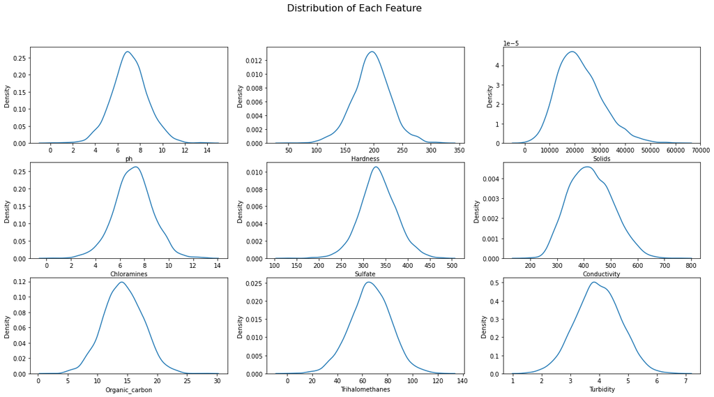

```python
# Plot Features Distributions
fig, axs = plt.subplots(3,3)
fig.suptitle('Distribution of Each Feature', fontsize=16)
for i in range(data.shape[1]-1):
    plt.subplot(3,3,i+1)
    sns.kdeplot(data[data.columns[i]])
```

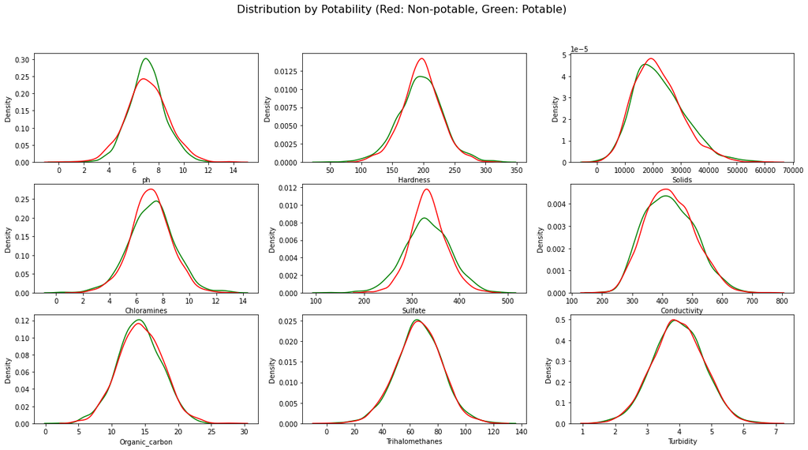

```python
# Plot Features Distributions
fig, axs = plt.subplots(3,3)
fig.suptitle('Distribution by Potability (Red: Non-potable, Green: Potable)', fontsize=16)
df_pot = data[data['Potability']==1]
df_non_pot = data[data['Potability']==0]

for i in range(data.shape[1]-1):
    plt.subplot(3,3,i+1)
    pot_var, non_pot_var = df_pot[data.columns[i]], df_non_pot[data.columns[i]]
    sns.kdeplot(data=pot_var,color='green')
    sns.kdeplot(data=non_pot_var, color='red')
```

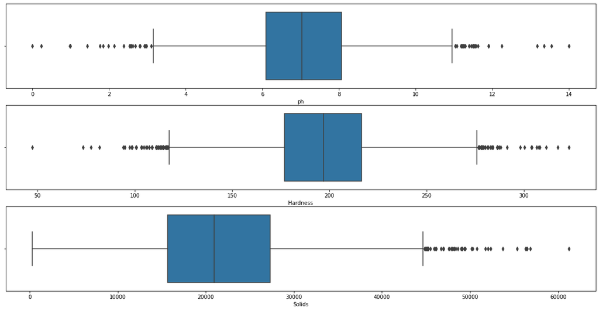

```python
# Outlier detection
fig, axs = plt.subplots(3,3)
for i in range(3):
    plt.subplot(3,1,i+1)
    sns.boxplot(x=data[data.columns[i]])
```

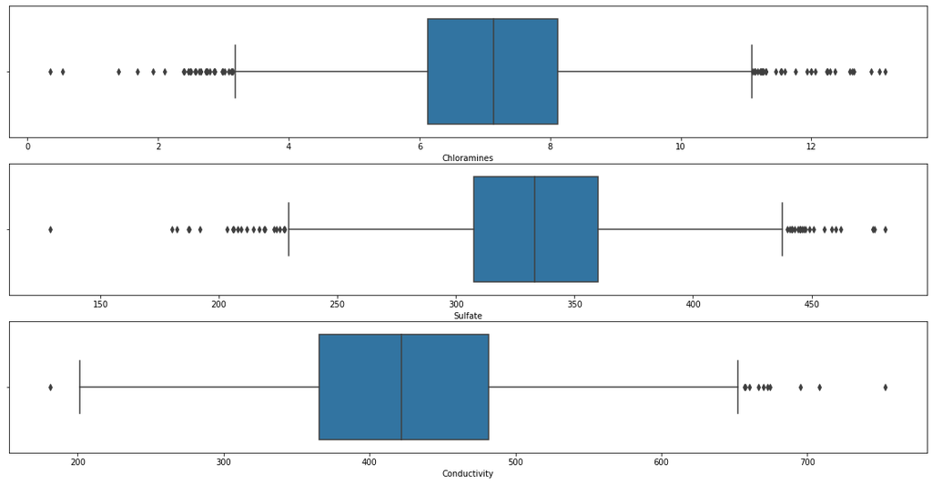

```python
fig, axs = plt.subplots(3,3)
for i in range(3):
    plt.subplot(3,1,i+1)
    sns.boxplot(x=data[data.columns[i+3]])
```

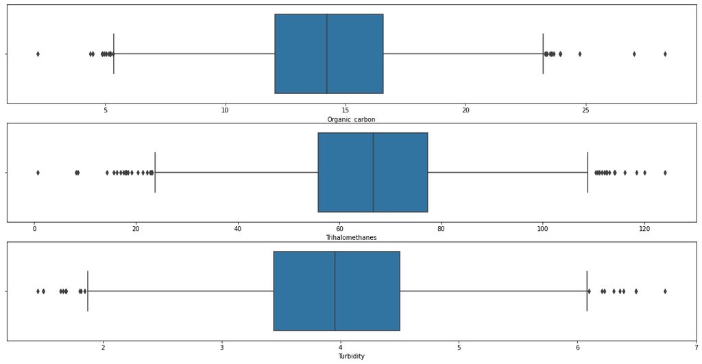

```python
fig, axs = plt.subplots(3,3)
for i in range(3):
    plt.subplot(3,1,i+1)
    sns.boxplot(x=data[data.columns[i+6]])
```

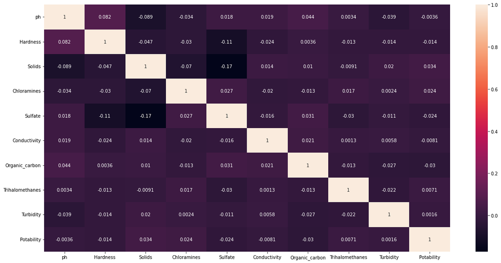

```python
#Feature correlation
corr_heat = sns.heatmap(data.corr(),annot=True)
```

```python
# Distribution of dependent variable.
data['Potability'].value_counts()
```

```
0    1998
1    1278
Name: Potability, dtype: int64
```

# Data pre-processing & transformation-------------------------------------------------------

```python
#Impute missing values
from sklearn.impute import KNNImputer
data = pd.DataFrame(KNNImputer(copy=False).fit_transform(data),columns=data.columns)

# Percentage of missing values
data.isnull().sum()/data.shape[0]
```

```
ph                 0.0
Hardness           0.0
Solids             0.0
Chloramines        0.0
Sulfate            0.0
Conductivity       0.0
Organic_carbon     0.0
Trihalomethanes    0.0
Turbidity          0.0
Potability         0.0
dtype: float64
```

```python
# Augment data with resampling and plot new distribution of points.
from sklearn.utils import resample, shuffle
non_potable = data[data['Potability']==0]
potable = data[data['Potability']==1]
print("Potable samples: {}".format(potable.shape[0]))

#resample potable data points
resampled_potable = resample(potable, n_samples=non_potable.shape[0]+100,random_state=seed)
print("Resampled potable samples: {}".format(resampled_potable.shape[0]))

#Combine and shuffle the data.
data = shuffle(pd.concat([non_potable,resampled_potable]),random_state=seed)
print('New distribution of data:\n')
data['Potability'].value_counts()
```

```
Potable samples: 1278
Resampled potable samples: 2098
New distribution of data:
```

```
1.0    2098
0.0    1998
Name: Potability, dtype: int64
```

## Train/Test Split of data.

```python
X, y = data.loc[:, data.columns != 'Potability'], data['Potability']
X_train, X_test, y_train, y_test = train_test_split(X,y,test_size=0.2,random_state=seed)
X_train.head()
```

|  | ph | Hardness | Solids | Chloramines | Sulfate | Conductivity | Organic_carbon | Trihalomethanes | Turbidity |
| --- | --- | --- | --- | --- | --- | --- | --- | --- | --- |
| 2837 | 6.643734 | 202.413638 | 14110.920968 | 8.754110 | 340.975559 | 291.084744 | 15.954655 | 64.363793 | 3.920607 |
| 1927 | 7.430911 | 179.756708 | 25703.155201 | 7.287310 | 327.515609 | 311.093065 | 10.238271 | 42.075315 | 1.659799 |
| 2617 | 7.509350 | 192.467955 | 17045.600095 | 8.815845 | 346.741822 | 266.357744 | 15.930051 | 83.262529 | 4.321856 |
| 493 | 9.241198 | 223.691350 | 21610.581297 | 4.116183 | 332.215973 | 480.013056 | 12.725428 | 65.550704 | 5.265729 |
| 1058 | 7.775386 | 193.077168 | 15704.482093 | 7.881197 | 324.336203 | 301.753477 | 13.378165 | 89.051957 | 3.309472 |

```python
#----- Not neccesary to scale due to using tree based prediction models. ----
#scaler = StandardScaler().fit(X_train)
#scaled_X_train = pd.DataFrame(scaler.transform(X_train),index=X_train.index,columns=X_train.columns)
#scaled_X_train.head()
```

# Building models ---------------------------------------------------------------------------------------

```python
import warnings
warnings.filterwarnings('ignore')
from sklearn.model_selection import RandomizedSearchCV
from sklearn.ensemble import RandomForestClassifier
import xgboost as xgb
```

### Hyperparameter Tuning using Cross-Validation -----------------------------------------------------------------------------------------

```python
#Build models
xg_model = xgb.XGBClassifier(eval_metric='logloss',use_label_encoder=False,random_state=seed)
rf_model = RandomForestClassifier(random_state=seed)

#pipeline = Pipeline([('standard scaler', StandardScaler()),('xg_model',xg_model)])
param_grid = {'learning_rate':[0.01,0.05,0.1,0.2, 0.5,0.7,1],'n_estimators':[50,100,200,250,300,500,700]}
grid_xg = RandomizedSearchCV(xg_model, param_grid, random_state=seed)

#pipeline = Pipeline([('standard scaler', StandardScaler()),('rf_model',rf_model)])
params_rf = {'n_estimators':[100,200,250,300,500,700],'min_samples_leaf':[2,3,4, 5, 10, 20, 30]}
grid_rf = RandomizedSearchCV(rf_model, params_rf, random_state=seed)
```

```python
grid_xg.fit(X_train,y_train)
grid_rf.fit(X_train,y_train)
```

```
RandomizedSearchCV(estimator=RandomForestClassifier(random_state=42),
                   param_distributions={'min_samples_leaf': [2, 3, 4, 5, 10, 20,
                                                             30],
                                        'n_estimators': [100, 200, 250, 300,
                                                         500, 700]},
                   random_state=42)
```

```python
#Get best CV score and best parameters
print(grid_xg.best_score_,grid_xg.best_params_)
print(grid_rf.best_score_,grid_rf.best_params_)
```

```
0.784793800037237 {'n_estimators': 300, 'learning_rate': 0.2}
0.7964019735617204 {'n_estimators': 500, 'min_samples_leaf': 2}
```

### Test Best Model & Results ---------------------------------------------------------------------------------------------------------------------

```python
final_model = RandomForestClassifier(n_estimators=500, min_samples_leaf = 2, random_state=seed).fit(X_train,y_train)
prediction = final_model.predict(X_test)
```

```python
from sklearn.metrics import classification_report, confusion_matrix, ConfusionMatrixDisplay, RocCurveDisplay
report = classification_report(y_test,prediction)
cf = confusion_matrix(y_test,prediction)
disp = ConfusionMatrixDisplay(cf)

#Display results
print(report)
```

```
              precision    recall  f1-score   support

         0.0       0.87      0.84      0.86       411
         1.0       0.85      0.87      0.86       409

    accuracy                           0.86       820
   macro avg       0.86      0.86      0.86       820
weighted avg       0.86      0.86      0.86       820
```

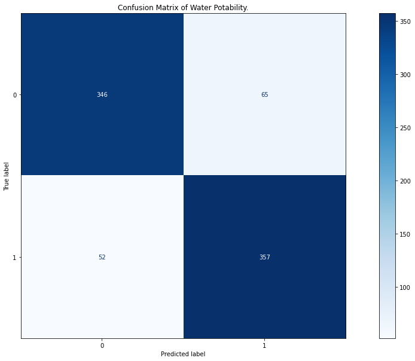

```python
disp.plot(cmap=plt.cm.Blues)
plt.title('Confusion Matrix of Water Potability.')
plt.show()
```

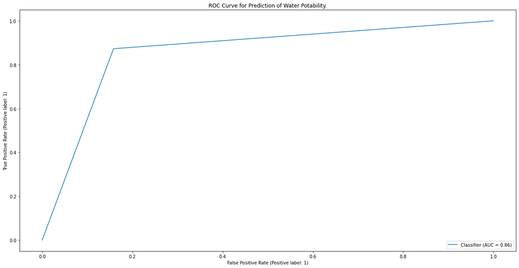

```python
RocCurveDisplay.from_predictions(y_test,prediction)
plt.title('ROC Curve for Prediction of Water Potability.')
```

## Extra Insights ------------------------------------------------------------------------------------------------------------

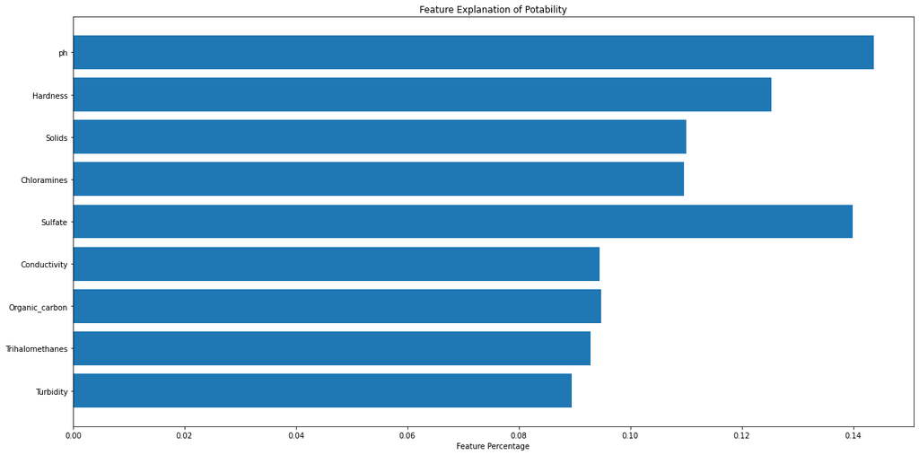

```python
feature_importance = final_model.feature_importances_
names = final_model.feature_names_in_

fig, ax = plt.subplots()
ax.barh(range(len(names)), feature_importance)
ax.set_yticks(range(len(names)), labels=names)

ax.invert_yaxis()  # labels read top-to-bottom
ax.set_xlabel('Feature Percentage')
ax.set_title('Feature Explanation of Potability')
```